# MSDS 6306 Project 2

```r
summary(model.main2)
```

```
##
## Call:
## glm(formula = Attrition ~ ., family = binomial(link = "logit"),
##     data = ddsdata_train_upsample_new1)
##
## Deviance Residuals:
##     Min       1Q   Median       3Q      Max
## -3.5059  -0.3927   0.0068   0.4674   2.4336
##
## Coefficients:
##                                 Estimate Std. Error z value Pr(>|z|)
## (Intercept)                      6.59443    1.38371   4.766 1.88e-06 ***
## Age                             -0.02406    0.01526  -1.576 0.114944
## BusinessTravelTravel_Frequently  2.36475    0.49341   4.793 1.65e-06 ***
## BusinessTravelTravel_Rarely      2.22835    0.44196   5.042 4.61e-07 ***
## DistanceFromHome                 0.06852    0.01350   5.076 3.86e-07 ***
## EnvironmentSatisfaction2        -1.35929    0.35704  -3.807 0.000141 ***
## EnvironmentSatisfaction3        -0.94029    0.31090  -3.024 0.002491 **
## EnvironmentSatisfaction4        -0.88439    0.31760  -2.785 0.005359 **
## JobInvolvement2                 -2.14980    0.48328  -4.448 8.65e-06 ***
## JobInvolvement3                 -2.66753    0.46066  -5.791 7.01e-09 ***
## JobInvolvement4                 -4.47315    0.68330  -6.546 5.89e-11 ***
## JobRoleHuman Resources           0.18388    0.72873   0.252 0.800782
## JobRoleLaboratory Technician     0.45612    0.46144   0.988 0.322919
## JobRoleManager                  -0.01709    0.60431  -0.028 0.977443
## JobRoleManufacturing Director   -3.17456    0.74480  -4.262 2.02e-05 ***
## JobRoleResearch Director        -2.93399    0.95322  -3.078 0.002084 **
## JobRoleResearch Scientist       -0.29537    0.47438  -0.623 0.533521
## JobRoleSales Executive          -0.44597    0.46204  -0.965 0.334427
## JobRoleSales Representative      3.09589    0.57967   5.341 9.25e-08 ***
## JobSatisfaction2                -1.05463    0.33726  -3.127 0.001766 **
## JobSatisfaction3                -1.45398    0.31596  -4.602 4.19e-06 ***
## JobSatisfaction4                -2.55448    0.35555  -7.185 6.74e-13 ***
## MaritalStatusMarried             1.26817    0.36942   3.433 0.000597 ***
## MaritalStatusSingle              0.99230    0.50008   1.984 0.047222 *
## NumCompaniesWorked               0.27018    0.05372   5.030 4.91e-07 ***
## OverTimeYes                      2.26425    0.24818   9.124  < 2e-16 ***
## PercentSalaryHike               -0.06541    0.04823  -1.356 0.175083
## PerformanceRating4               0.91103    0.53209   1.712 0.086866 .
## RelationshipSatisfaction2       -0.93235    0.36456  -2.557 0.010545 *
```

[output cut: 14 more lines]

```
## WorkLifeBalance4                -2.16986    0.56097  -3.868 0.000110 ***
## YearsAtCompany                   0.20564    0.04123   4.987 6.13e-07 ***
## YearsInCurrentRole              -0.07243    0.05605  -1.292 0.196241
## YearsSinceLastPromotion          0.23778    0.04856   4.896 9.76e-07 ***
## YearsWithCurrManager            -0.21551    0.04926  -4.375 1.21e-05 ***
## ---
## Signif. codes:  0 '***' 0.001 '**' 0.01 '*' 0.05 '.' 0.1 ' ' 1
##
## (Dispersion parameter for binomial family taken to be 1)
##
##     Null deviance: 1416.79  on 1021  degrees of freedom
## Residual deviance:  654.01  on  974  degrees of freedom
## AIC: 750.01
##
## Number of Fisher Scoring iterations: 6
```

```r
exp(cbind("Odds ratio" = coef(model.main2), confint.default(model.main2, level = 0.95)))
```

```
##                                   Odds ratio        2.5 %       97.5 %
## (Intercept)                     731.01216344 48.541298196 1.100875e+04
## Age                               0.97622976  0.947461460 1.005872e+00
## BusinessTravelTravel_Frequently  10.64133081  4.045806456 2.798896e+01
## BusinessTravelTravel_Rarely       9.28449535  3.904428593 2.207797e+01
## DistanceFromHome                  1.07092647  1.042962026 1.099641e+00
## EnvironmentSatisfaction2          0.25684263  0.127570768 5.171101e-01
## EnvironmentSatisfaction3          0.39051595  0.212325606 7.182493e-01
## EnvironmentSatisfaction4          0.41296612  0.221601363 7.695847e-01
## JobInvolvement2                   0.11650697  0.045184035 3.004131e-01
## JobInvolvement3                   0.06942375  0.028144724 1.712455e-01
## JobInvolvement4                   0.01141135  0.002990278 4.354741e-02
## JobRoleHuman Resources            1.20187695  0.288113124 5.013684e+00
## JobRoleLaboratory Technician      1.57794546  0.638723981 3.898260e+00
## JobRoleManager                    0.98305817  0.300740404 3.213414e+00
## JobRoleManufacturing Director     0.04181251  0.009712424 1.800051e-01
## JobRoleResearch Director          0.05318463  0.008211146 3.444836e-01
## JobRoleResearch Scientist         0.74425836  0.293718817 1.885887e+00
## JobRoleSales Executive            0.64020013  0.258838575 1.583443e+00
## JobRoleSales Representative      22.10680638  7.097613037 6.885567e+01
## JobSatisfaction2                  0.34832217  0.179846699 6.746209e-01
## JobSatisfaction3                  0.23363819  0.125776756 4.339975e-01
## JobSatisfaction4                  0.07773274  0.038722118 1.560446e-01
## MaritalStatusMarried              3.55435602  1.723098461 7.331819e+00
## MaritalStatusSingle               2.69744248  1.012244811 7.188178e+00
## NumCompaniesWorked                1.31019516  1.179267436 1.455659e+00
## OverTimeYes                       9.62388712  5.917004288 1.565306e+01
## PercentSalaryHike                 0.93668760  0.852195815 1.029556e+00
## PerformanceRating4                2.48689285  0.876469955 7.056301e+00
## RelationshipSatisfaction2         0.39362864  0.192649856 8.042752e-01
## RelationshipSatisfaction3         0.24354372  0.127130695 4.665557e-01
## RelationshipSatisfaction4         0.55947053  0.311373832 1.005246e+00
## StockOptionLevel1                 0.19643292  0.094212931 4.095605e-01
## StockOptionLevel2                 0.11555692  0.038303325 3.486225e-01
## StockOptionLevel3                 0.47662427  0.142229717 1.597210e+00
## TotalWorkingYears                 0.85754024  0.804836749 9.136949e-01
## TrainingTimesLastYear1            0.29715378  0.081187627 1.087609e+00
## TrainingTimesLastYear2            0.12442771  0.041028046 3.773579e-01
## TrainingTimesLastYear3            0.09964049  0.033460619 2.967138e-01
## TrainingTimesLastYear4            0.28507868  0.084893096 9.573200e-01
## TrainingTimesLastYear5            0.03849058  0.009020029 1.642483e-01
## TrainingTimesLastYear6            0.12776830  0.029474744 5.538551e-01
## WorkLifeBalance2                  0.18145700  0.069512431 4.736799e-01
## WorkLifeBalance3                  0.14375693  0.056295831 3.670974e-01
## WorkLifeBalance4                  0.11419325  0.038031498 3.428763e-01
## YearsAtCompany                    1.22830555  1.132942727 1.331695e+00
## YearsInCurrentRole                0.93013110  0.833370447 1.038126e+00
## YearsSinceLastPromotion           1.26842874  1.153268242 1.395089e+00
## YearsWithCurrManager              0.80612627  0.731936201 8.878363e-01
```

# Lack of fit test - Hosmer Lemeshow test to check the lack of fit.

We then run the Hosmer Lemeshow test to check the lack of fit. And the Hosmer Lemeshow test looks fine since p-value > 0.05. Hence, we conclude that the model is a good fit.

```
##
##  Hosmer and Lemeshow goodness of fit (GOF) test
##
## data:  model.main2$y, fitted(model.main2)
## X-squared = 11.227, df = 8, p-value = 0.1892
```

# Residual diagnostics - Plots here help us examine Cook’s D graph:

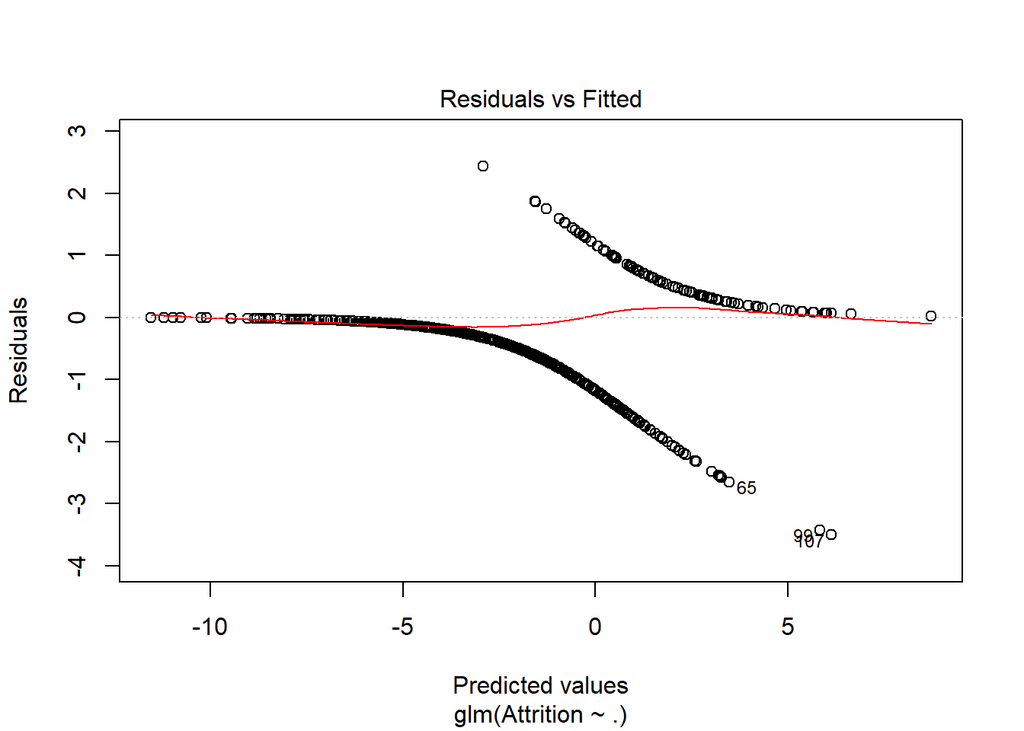

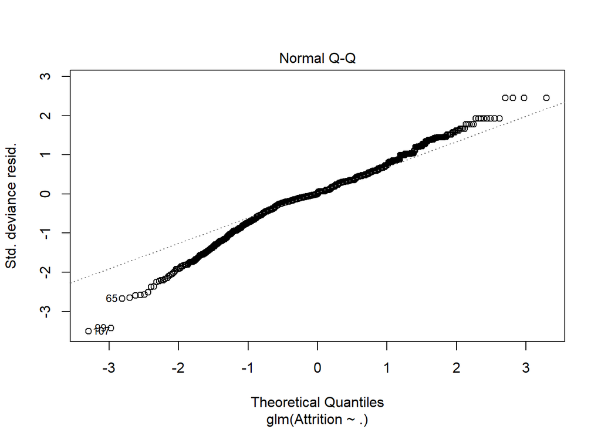

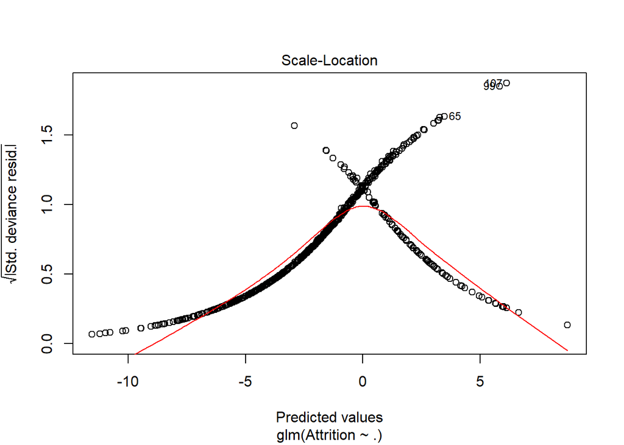

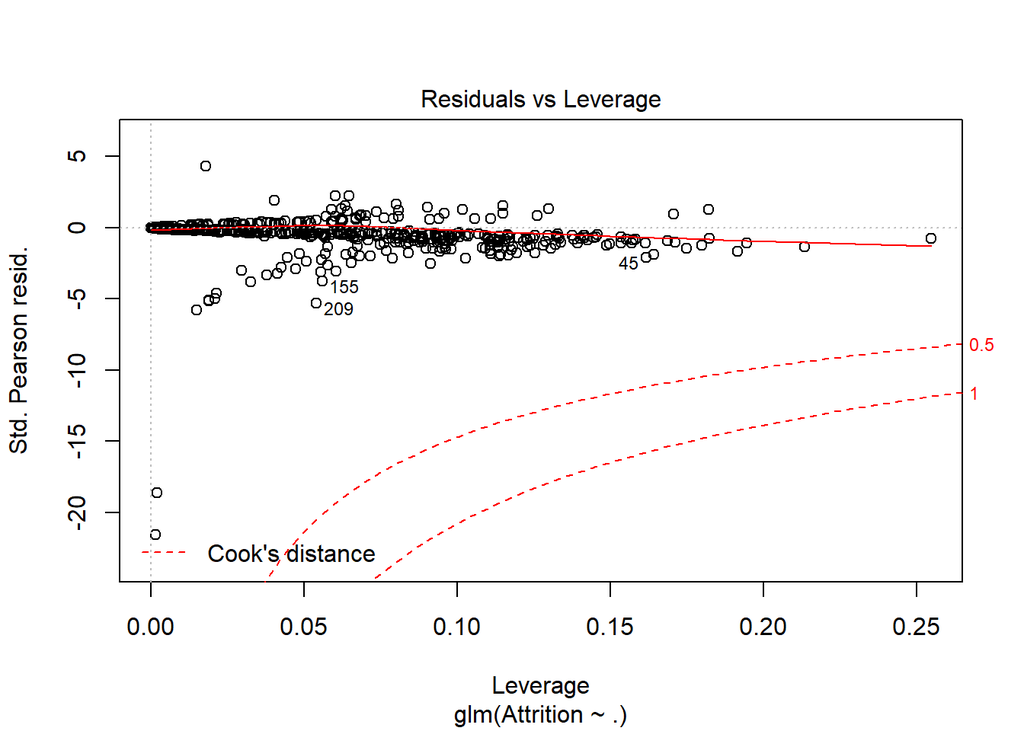

When checking Cook’s D plot, if observations are outside the Cook’s distance (meaning they have a high Cook’s distance score) the observations are influential to the regression results. In this case, from the Cook’s D plot above, we do not see any influential points.

# Confusion Matrix for Training and test datasets and ROC plot

```r
model.main2<-glm(Attrition ~ . , data=ddsdata_train_upsample_new1,family = binomial(link="logit"))

summary(model.main2)
```

```
##
## Call:
## glm(formula = Attrition ~ ., family = binomial(link = "logit"),
##     data = ddsdata_train_upsample_new1)
##
## Deviance Residuals:
##     Min       1Q   Median       3Q      Max
## -3.5059  -0.3927   0.0068   0.4674   2.4336
##
## Coefficients:
##                                 Estimate Std. Error z value Pr(>|z|)
## (Intercept)                      6.59443    1.38371   4.766 1.88e-06 ***
## Age                             -0.02406    0.01526  -1.576 0.114944
## BusinessTravelTravel_Frequently  2.36475    0.49341   4.793 1.65e-06 ***
## BusinessTravelTravel_Rarely      2.22835    0.44196   5.042 4.61e-07 ***
## DistanceFromHome                 0.06852    0.01350   5.076 3.86e-07 ***
## EnvironmentSatisfaction2        -1.35929    0.35704  -3.807 0.000141 ***
## EnvironmentSatisfaction3        -0.94029    0.31090  -3.024 0.002491 **
## EnvironmentSatisfaction4        -0.88439    0.31760  -2.785 0.005359 **
## JobInvolvement2                 -2.14980    0.48328  -4.448 8.65e-06 ***
## JobInvolvement3                 -2.66753    0.46066  -5.791 7.01e-09 ***
## JobInvolvement4                 -4.47315    0.68330  -6.546 5.89e-11 ***
## JobRoleHuman Resources           0.18388    0.72873   0.252 0.800782
## JobRoleLaboratory Technician     0.45612    0.46144   0.988 0.322919
## JobRoleManager                  -0.01709    0.60431  -0.028 0.977443
## JobRoleManufacturing Director   -3.17456    0.74480  -4.262 2.02e-05 ***
## JobRoleResearch Director        -2.93399    0.95322  -3.078 0.002084 **
## JobRoleResearch Scientist       -0.29537    0.47438  -0.623 0.533521
## JobRoleSales Executive          -0.44597    0.46204  -0.965 0.334427
## JobRoleSales Representative      3.09589    0.57967   5.341 9.25e-08 ***
## JobSatisfaction2                -1.05463    0.33726  -3.127 0.001766 **
## JobSatisfaction3                -1.45398    0.31596  -4.602 4.19e-06 ***
## JobSatisfaction4                -2.55448    0.35555  -7.185 6.74e-13 ***
## MaritalStatusMarried             1.26817    0.36942   3.433 0.000597 ***
## MaritalStatusSingle              0.99230    0.50008   1.984 0.047222 *
## NumCompaniesWorked               0.27018    0.05372   5.030 4.91e-07 ***
## OverTimeYes                      2.26425    0.24818   9.124  < 2e-16 ***
## PercentSalaryHike               -0.06541    0.04823  -1.356 0.175083
## PerformanceRating4               0.91103    0.53209   1.712 0.086866 .
## RelationshipSatisfaction2       -0.93235    0.36456  -2.557 0.010545 *
```

[output cut: 14 more lines]

```
## WorkLifeBalance4                -2.16986    0.56097  -3.868 0.000110 ***
## YearsAtCompany                   0.20564    0.04123   4.987 6.13e-07 ***
## YearsInCurrentRole              -0.07243    0.05605  -1.292 0.196241
## YearsSinceLastPromotion          0.23778    0.04856   4.896 9.76e-07 ***
## YearsWithCurrManager            -0.21551    0.04926  -4.375 1.21e-05 ***
## ---
## Signif. codes:  0 '***' 0.001 '**' 0.01 '*' 0.05 '.' 0.1 ' ' 1
##
## (Dispersion parameter for binomial family taken to be 1)
##
##     Null deviance: 1416.79  on 1021  degrees of freedom
## Residual deviance:  654.01  on  974  degrees of freedom
## AIC: 750.01
##
## Number of Fisher Scoring iterations: 6
```

```r
bal.pred_probs <- predict(model.main2, ddsdata_train_upsample_new1, type="response")
bal.pred_yns <- factor(ifelse(bal.pred_probs>0.5, "Yes", "No"))
bal.cm <- confusionMatrix(table(bal.pred_yns, ddsdata_train_upsample_new1$Attrition))

bal.cm
```

```
## Confusion Matrix and Statistics
##
##
## bal.pred_yns  No Yes
##          No  435  67
##          Yes  76 444
##
##                Accuracy : 0.8601
##                  95% CI : (0.8373, 0.8808)
##     No Information Rate : 0.5
##     P-Value [Acc > NIR] : <2e-16
##
##                   Kappa : 0.7202
##
##  Mcnemar's Test P-Value : 0.5035
##
##             Sensitivity : 0.8513
##             Specificity : 0.8689
##          Pos Pred Value : 0.8665
##          Neg Pred Value : 0.8538
##              Prevalence : 0.5000
##          Detection Rate : 0.4256
##    Detection Prevalence : 0.4912
##       Balanced Accuracy : 0.8601
##
##        'Positive' Class : No
##
```

```r
bal.pred_probs.test <- predict(model.main2, ddsdata_test, type="response")
bal.pred_yns.test <- factor(ifelse(bal.pred_probs.test>0.5, "Yes", "No"))
bal.cm.test <- confusionMatrix(table(bal.pred_yns.test, ddsdata_test$Attrition))

bal.cm.test
```

```
## Confusion Matrix and Statistics
##
##
## bal.pred_yns.test  No Yes
##               No  168  15
##               Yes  51  27
##
##                Accuracy : 0.7471
##                  95% CI : (0.6898, 0.7987)
##     No Information Rate : 0.8391
##     P-Value [Acc > NIR] : 0.9999
##
##                   Kappa : 0.3045
##
##  Mcnemar's Test P-Value : 1.646e-05
##
##             Sensitivity : 0.7671
##             Specificity : 0.6429
##          Pos Pred Value : 0.9180
##          Neg Pred Value : 0.3462
##              Prevalence : 0.8391
##          Detection Rate : 0.6437
##    Detection Prevalence : 0.7011
##       Balanced Accuracy : 0.7050
##
##        'Positive' Class : No
##
```

```r
df <- rbind(data.frame(predictor = predict(model.main2, ddsdata_train_upsample_new1),
                       known.truth = ddsdata_train_upsample_new1$Attrition,
                       model = "Train"),
            data.frame(predictor = predict(model.main2, ddsdata_test),
                       known.truth = ddsdata_test$Attrition,
                       model = "Test"))

# the aesthetic names are not the most intuitive
# `d` holds the known truth
# `m` holds the predictor values

ggroc <- ggplot(df, aes(d = known.truth, m = predictor, color = model)) +
  geom_roc(n.cuts = 0) + geom_abline(intercept = 0, slope = 1, linetype='dashed')

calc_auc(ggroc)
```

```
##   PANEL group       AUC
## 1     1     1 0.9355165
## 2     1     2 0.8176778
```

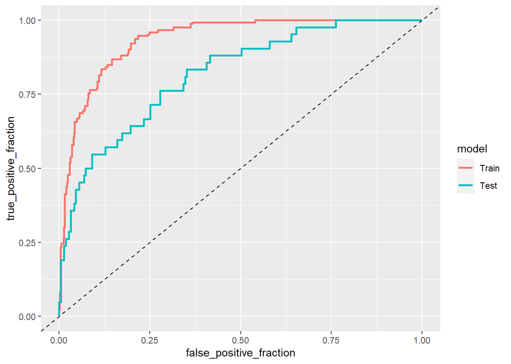

```r
ggroc
```

## Predicting Attrition for Dataset with no Attrition

```r
ddsdata_pred<-read.csv("CaseStudy2CompSet No Attrition.csv",header=T)

ddsdata_pred$Education <- as.factor(ddsdata_pred$Education)
ddsdata_pred$EnvironmentSatisfaction <- as.factor(ddsdata_pred$EnvironmentSatisfaction)
ddsdata_pred$JobInvolvement <- as.factor(ddsdata_pred$JobInvolvement)
ddsdata_pred$JobLevel <- as.factor(ddsdata_pred$JobLevel)
ddsdata_pred$JobSatisfaction <- as.factor(ddsdata_pred$JobSatisfaction)
ddsdata_pred$PerformanceRating <- as.factor(ddsdata_pred$PerformanceRating)
ddsdata_pred$RelationshipSatisfaction <- as.factor(ddsdata_pred$RelationshipSatisfaction)
ddsdata_pred$StockOptionLevel <- as.factor(ddsdata_pred$StockOptionLevel)
ddsdata_pred$TrainingTimesLastYear <- as.factor(ddsdata_pred$TrainingTimesLastYear)
ddsdata_pred$WorkLifeBalance <- as.factor(ddsdata_pred$WorkLifeBalance)


ddsdata_pred_new = ddsdata_pred %>% dplyr::select(-c('Education', 'EducationField', 'HourlyRate', 'JobLevel', 'MonthlyIncome', 'MonthlyRate', 'DailyRate', 'Gender', 'Department', 'EmployeeCount', 'Over18', 'StandardHours', 'EmployeeNumber'))


#Predicting Attrition for Dataset with no Attrition
PredictedAT <- predict(model.main2,newdata = ddsdata_pred_new,type = 'response')
ddsdata_pred_new$Attrition <- PredictedAT
ddsdata_pred_new$Attrition <- factor(ifelse(ddsdata_pred_new$Attrition>0.5, "Yes", "No"))
head(ddsdata_pred_new)
```

```
##     ID Age    BusinessTravel DistanceFromHome EnvironmentSatisfaction
## 1 1171  35     Travel_Rarely               28                       2
## 2 1172  33     Travel_Rarely                2                       2
## 3 1173  26     Travel_Rarely               21                       1
## 4 1174  55     Travel_Rarely                2                       3
## 5 1175  29     Travel_Rarely               19                       3
## 6 1176  51 Travel_Frequently                1                       1
##   JobInvolvement                   JobRole JobSatisfaction MaritalStatus
## 1              4     Laboratory Technician               3       Married
## 2              3           Human Resources               3       Married
## 3              3     Laboratory Technician               3      Divorced
## 4              3                   Manager               4        Single
## 5              2           Sales Executive               3      Divorced
## 6              2 Healthcare Representative               1        Single
##   NumCompaniesWorked OverTime PercentSalaryHike PerformanceRating
```

[output cut: 27 more lines]

```r
dim(ddsdata_pred_new)
```

```
## [1] 300  23
```

```r
#Exporting Results to .csv
write.csv(ddsdata_pred_new[,c(1,23)],"Case2Predictions Attrition.csv")
```

# Attrition by Job Role

Let’s analyze job role versus attrition to see if we can identify any patterns. By simply looking a the count of attrition by job role, it looks like Sales Eecutive, Research Scientist and Labratory Technician roles have highest attrition by count. However, this is misleading as there are a lot more people in those roles. Let’s look at attrition as a percent of people to give a more accurate picture of what’s going on.

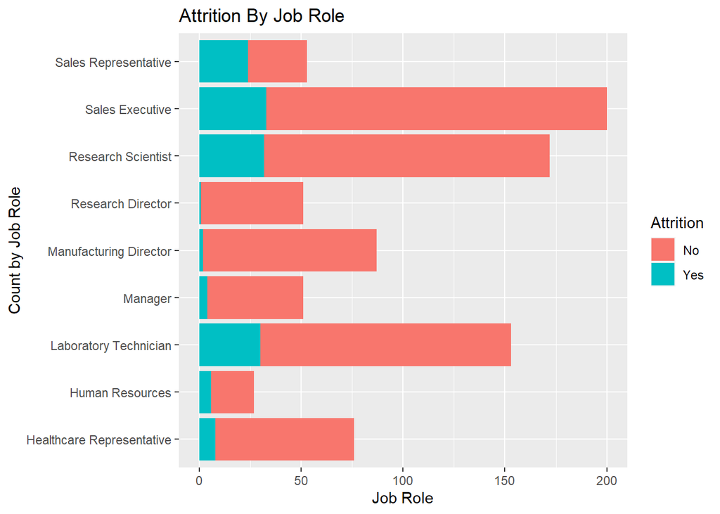

```r
ddsdata %>% ggplot(mapping=aes(x=JobRole, fill=Attrition)) + geom_bar() + coord_flip() + ggtitle("Attrition By Job Role") + xlab("Count by Job Role") + ylab("Job Role")
```

Now, when we see count plot of attrition as a percent by each role, we get a different picture. We see that the top roles for attrition are: + Sales Representative (45.3%) + Human Resources (22.2%) + Laboratory Techician (19.6)

```r
CrossTable(ddsdata$JobRole, ddsdata$Attrition)
```

```
##
##
##    Cell Contents
## |-------------------------|
## |                       N |
## | Chi-square contribution |
## |           N / Row Total |
## |           N / Col Total |
## |         N / Table Total |
## |-------------------------|
##
##
## Total Observations in Table:  870
##
##
##                           | ddsdata$Attrition
##           ddsdata$JobRole |        No |       Yes | Row Total |
## --------------------------|-----------|-----------|-----------|
## Healthcare Representative |        68 |         8 |        76 |
##                           |     0.281 |     1.463 |           |
##                           |     0.895 |     0.105 |     0.087 |
##                           |     0.093 |     0.057 |           |
##                           |     0.078 |     0.009 |           |
## --------------------------|-----------|-----------|-----------|
##           Human Resources |        21 |         6 |        27 |
##                           |     0.121 |     0.631 |           |
##                           |     0.778 |     0.222 |     0.031 |
##                           |     0.029 |     0.043 |           |
##                           |     0.024 |     0.007 |           |
## --------------------------|-----------|-----------|-----------|
##     Laboratory Technician |       123 |        30 |       153 |
##                           |     0.225 |     1.175 |           |
##                           |     0.804 |     0.196 |     0.176 |
##                           |     0.168 |     0.214 |           |
##                           |     0.141 |     0.034 |           |
## --------------------------|-----------|-----------|-----------|
##                   Manager |        47 |         4 |        51 |
##                           |     0.414 |     2.156 |           |
##                           |     0.922 |     0.078 |     0.059 |
##                           |     0.064 |     0.029 |           |
```

[output cut: 22 more lines]

```
##                           |     0.835 |     0.165 |     0.230 |
##                           |     0.229 |     0.236 |           |
##                           |     0.192 |     0.038 |           |
## --------------------------|-----------|-----------|-----------|
##      Sales Representative |        29 |        24 |        53 |
##                           |     5.382 |    28.065 |           |
##                           |     0.547 |     0.453 |     0.061 |
##                           |     0.040 |     0.171 |           |
##                           |     0.033 |     0.028 |           |
## --------------------------|-----------|-----------|-----------|
##              Column Total |       730 |       140 |       870 |
##                           |     0.839 |     0.161 |           |
## --------------------------|-----------|-----------|-----------|
##
##
```

# Linear Regression model - Montly Income

## Model selection “Forward” and train and test Plot

```r
set.seed(1234)
reg.fwd=regsubsets(MonthlyIncome~., data=ddsdata_train_upsample, method="forward", nvmax=20)

reg.fwd
```

```
## Subset selection object
## Call: regsubsets.formula(MonthlyIncome ~ ., data = ddsdata_train_upsample,
##     method = "forward", nvmax = 20)
## 67 Variables  (and intercept)
##                                  Forced in Forced out
## Age                                  FALSE      FALSE
## BusinessTravelTravel_Frequently      FALSE      FALSE
## BusinessTravelTravel_Rarely          FALSE      FALSE
## DailyRate                            FALSE      FALSE
## DepartmentResearch & Development     FALSE      FALSE
## DepartmentSales                      FALSE      FALSE
## DistanceFromHome                     FALSE      FALSE
## Education2                           FALSE      FALSE
## Education3                           FALSE      FALSE
## Education4                           FALSE      FALSE
## Education5                           FALSE      FALSE
## EducationFieldLife Sciences          FALSE      FALSE
## EducationFieldMarketing              FALSE      FALSE
## EducationFieldMedical                FALSE      FALSE
## EducationFieldOther                  FALSE      FALSE
## EducationFieldTechnical Degree       FALSE      FALSE
## EnvironmentSatisfaction2             FALSE      FALSE
## EnvironmentSatisfaction3             FALSE      FALSE
## EnvironmentSatisfaction4             FALSE      FALSE
## GenderMale                           FALSE      FALSE
## HourlyRate                           FALSE      FALSE
## JobInvolvement2                      FALSE      FALSE
## JobInvolvement3                      FALSE      FALSE
## JobInvolvement4                      FALSE      FALSE
## JobLevel2                            FALSE      FALSE
## JobLevel3                            FALSE      FALSE
## JobLevel4                            FALSE      FALSE
## JobLevel5                            FALSE      FALSE
## JobRoleHuman Resources               FALSE      FALSE
## JobRoleLaboratory Technician         FALSE      FALSE
## JobRoleManager                       FALSE      FALSE
## JobRoleManufacturing Director        FALSE      FALSE
## JobRoleResearch Director             FALSE      FALSE
## JobRoleResearch Scientist            FALSE      FALSE
## JobRoleSales Executive               FALSE      FALSE
```

[output cut: 19 more lines]

```
## TrainingTimesLastYear2               FALSE      FALSE
## TrainingTimesLastYear3               FALSE      FALSE
## TrainingTimesLastYear4               FALSE      FALSE
## TrainingTimesLastYear5               FALSE      FALSE
## TrainingTimesLastYear6               FALSE      FALSE
## WorkLifeBalance2                     FALSE      FALSE
## WorkLifeBalance3                     FALSE      FALSE
## WorkLifeBalance4                     FALSE      FALSE
## YearsAtCompany                       FALSE      FALSE
## YearsInCurrentRole                   FALSE      FALSE
## YearsSinceLastPromotion              FALSE      FALSE
## YearsWithCurrManager                 FALSE      FALSE
## AttritionYes                         FALSE      FALSE
## 1 subsets of each size up to 20
## Selection Algorithm: forward
```

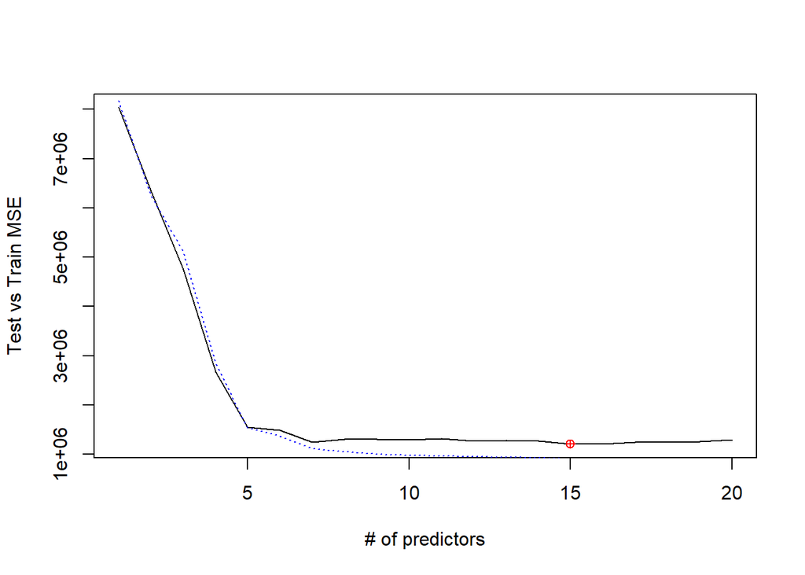

```r
predict.regsubsets =function (object , newdata ,id ,...){
  form=as.formula (object$call [[2]])
  mat=model.matrix(form ,newdata )
  coefi=coef(object ,id=id)
  xvars=names(coefi)
  mat[,xvars]%*%coefi
}

testASE<-c()
#note my index is to 20 since that what I set it in regsubsets
for (i in 1:20){
  predictions<-predict.regsubsets(object=reg.fwd,newdata=ddsdata_test,id=i)
  testASE[i]<-mean((ddsdata_test$MonthlyIncome-predictions)^2)
}

par(mfrow=c(1,1))
plot(1:20,testASE,type="l",xlab="# of predictors",ylab="Test vs Train MSE")
index<-which(testASE==min(testASE))
points(index,testASE[index],col="red",pch=10)
rss<-summary(reg.fwd)$rss
lines(1:20,rss/1022,lty=3,col="blue")
```

## BIC, adj R-squared and RSS plots for forward selection

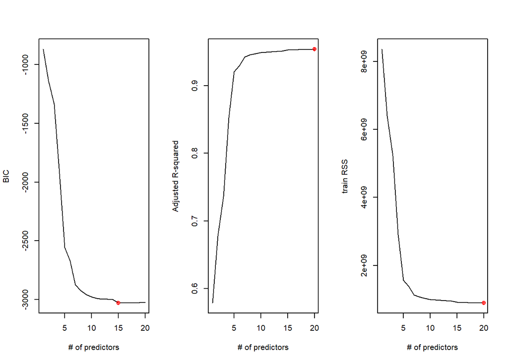

```r
par(mfrow=c(1,3))
bics<-summary(reg.fwd)$bic
plot(1:20,bics,type="l",ylab="BIC",xlab="# of predictors")
index<-which(bics==min(bics))
points(index,bics[index],col="red",pch=10)

adjr2<-summary(reg.fwd)$adjr2
plot(1:20,adjr2,type="l",ylab="Adjusted R-squared",xlab="# of predictors")
index<-which(adjr2==max(adjr2))
points(index,adjr2[index],col="red",pch=10)

rss<-summary(reg.fwd)$rss
plot(1:20,rss,type="l",ylab="train RSS",xlab="# of predictors")
index<-which(rss==min(rss))
points(index,rss[index],col="red",pch=10)
```

## Pick up the model

```r
m1<-coef(reg.fwd,14)
m1
```

```
##                      (Intercept)      BusinessTravelTravel_Rarely
##                       1983.39060                        440.48076
## DepartmentResearch & Development                        JobLevel2
##                        288.90940                       2163.58570
##                        JobLevel3                        JobLevel4
##                       5236.43068                       8764.85302
##                        JobLevel5     JobRoleLaboratory Technician
##                      11483.34648                       -529.44945
##                   JobRoleManager    JobRoleManufacturing Director
##                       3897.36837                        442.68973
##         JobRoleResearch Director           JobRoleSales Executive
##                       3985.05827                       1028.84869
##                StockOptionLevel1                TotalWorkingYears
##                        276.77014                         34.63805
##               YearsInCurrentRole
##                         31.52465
```

```r
fwd.Model1 = lm(MonthlyIncome~ BusinessTravel+TotalWorkingYears + JobRole + JobLevel+TrainingTimesLastYear+YearsSinceLastPromotion , data=ddsdata_train_upsample)

summary(fwd.Model1)
```

```
##
## Call:
## lm(formula = MonthlyIncome ~ BusinessTravel + TotalWorkingYears +
##     JobRole + JobLevel + TrainingTimesLastYear + YearsSinceLastPromotion,
##     data = ddsdata_train_upsample)
##
## Residuals:
##     Min      1Q  Median      3Q     Max
## -2488.6  -566.0  -115.0   493.8  4354.7
##
## Coefficients:
##                                  Estimate Std. Error t value Pr(>|t|)
## (Intercept)                      3520.157    233.699  15.063  < 2e-16 ***
## BusinessTravelTravel_Frequently   134.173    126.206   1.063   0.2880
## BusinessTravelTravel_Rarely       533.407    106.810   4.994 6.98e-07 ***
## TotalWorkingYears                  38.949      7.046   5.528 4.13e-08 ***
## JobRoleHuman Resources          -1653.803    230.047  -7.189 1.28e-12 ***
## JobRoleLaboratory Technician    -1501.352    163.893  -9.161  < 2e-16 ***
## JobRoleManager                   3579.016    225.604  15.864  < 2e-16 ***
## JobRoleManufacturing Director     -24.621    161.463  -0.152   0.8788
## JobRoleResearch Director         3698.987    204.837  18.058  < 2e-16 ***
## JobRoleResearch Scientist       -1238.149    168.480  -7.349 4.15e-13 ***
## JobRoleSales Executive            190.554    126.052   1.512   0.1309
## JobRoleSales Representative     -1453.614    192.261  -7.561 9.07e-14 ***
## JobLevel2                        1647.541    133.505  12.341  < 2e-16 ***
## JobLevel3                        4573.962    176.303  25.944  < 2e-16 ***
## JobLevel4                        7850.614    261.372  30.036  < 2e-16 ***
## JobLevel5                       10585.097    311.781  33.950  < 2e-16 ***
## TrainingTimesLastYear1           -346.846    203.350  -1.706   0.0884 .
## TrainingTimesLastYear2           -177.613    162.185  -1.095   0.2737
## TrainingTimesLastYear3            -67.924    162.590  -0.418   0.6762
## TrainingTimesLastYear4             18.470    183.691   0.101   0.9199
## TrainingTimesLastYear5           -111.903    197.938  -0.565   0.5720
## TrainingTimesLastYear6            -38.278    212.760  -0.180   0.8573
## YearsSinceLastPromotion            23.836     11.110   2.145   0.0322 *
## ---
## Signif. codes:  0 '***' 0.001 '**' 0.01 '*' 0.05 '.' 0.1 ' ' 1
##
## Residual standard error: 959.1 on 999 degrees of freedom
## Multiple R-squared:  0.9537, Adjusted R-squared:  0.9527
## F-statistic: 935.6 on 22 and 999 DF,  p-value: < 2.2e-16
```

## Let’s check the residual Sum of Squares, Mean Squared Error and Root Mean Squared Error for forward selection model

```r
#residual sum of squares
fwd.RSS = c(crossprod(fwd.Model1$residuals))
fwd.RSS
```

```
## [1] 918983742
```

```r
#Mean Squared Error
fwd.MSE = fwd.RSS / length(fwd.Model1$residuals)
fwd.MSE
```

```
## [1] 899201.3
```

```r
#Root MSE
fwd.RMSE = sqrt(fwd.MSE)
fwd.RMSE
```

```
## [1] 948.2623
```

```r
fwd.pred<-predict(fwd.Model1, newdata=ddsdata_test)
TestMSE<-mean((ddsdata_test$MonthlyIncome-fwd.pred)^2)

TESTRMSE = sqrt(TestMSE)
TESTRMSE
```

```
## [1] 1098.231
```

# Model selection “backward” and train and test Plot

```r
reg.bkd=regsubsets(MonthlyIncome~., data=ddsdata_train_upsample, method="backward", nvmax=20)
str(ddsdata_train_upsample)
```

```
## 'data.frame':    1022 obs. of  31 variables:
##  $ Age                     : int  53 29 40 31 53 26 24 40 30 38 ...
##  $ BusinessTravel          : Factor w/ 3 levels "Non-Travel","Travel_Frequently",..: 3 3 1 1 3 3 3 3 3 3 ...
##  $ DailyRate               : int  970 590 218 976 447 1355 823 302 1138 1035 ...
##  $ Department              : Factor w/ 3 levels "Human Resources",..: 2 2 2 2 2 1 2 2 2 3 ...
##  $ DistanceFromHome        : int  7 4 8 3 2 25 17 6 6 3 ...
##  $ Education               : Factor w/ 5 levels "1","2","3","4",..: 3 3 1 2 3 1 2 3 3 4 ...
##  $ EducationField          : Factor w/ 6 levels "Human Resources",..: 2 6 4 4 4 2 5 2 6 2 ...
##  $ EnvironmentSatisfaction : Factor w/ 4 levels "1","2","3","4": 3 4 4 3 4 3 4 2 1 2 ...
##  $ Gender                  : Factor w/ 2 levels "Female","Male": 2 1 2 2 2 1 2 1 1 2 ...
##  $ HourlyRate              : int  59 91 55 48 39 61 94 75 48 42 ...
##  $ JobInvolvement          : Factor w/ 4 levels "1","2","3","4": 4 2 2 3 4 3 2 3 2 3 ...
##  $ JobLevel                : Factor w/ 5 levels "1","2","3","4",..: 4 1 3 1 4 1 1 4 2 2 ...
##  $ JobRole                 : Factor w/ 9 levels "Healthcare Representative",..: 6 7 6 7 6 2 3 5 3 8 ...
##  $ JobSatisfaction         : Factor w/ 4 levels "1","2","3","4": 3 1 2 1 2 3 2 3 4 4 ...
```

[output cut: 17 more lines]

```r
reg.bkd
```

```
## Subset selection object
## Call: regsubsets.formula(MonthlyIncome ~ ., data = ddsdata_train_upsample,
##     method = "backward", nvmax = 20)
## 67 Variables  (and intercept)
##                                  Forced in Forced out
## Age                                  FALSE      FALSE
## BusinessTravelTravel_Frequently      FALSE      FALSE
## BusinessTravelTravel_Rarely          FALSE      FALSE
## DailyRate                            FALSE      FALSE
## DepartmentResearch & Development     FALSE      FALSE
## DepartmentSales                      FALSE      FALSE
## DistanceFromHome                     FALSE      FALSE
## Education2                           FALSE      FALSE
## Education3                           FALSE      FALSE
## Education4                           FALSE      FALSE
## Education5                           FALSE      FALSE
## EducationFieldLife Sciences          FALSE      FALSE
## EducationFieldMarketing              FALSE      FALSE
## EducationFieldMedical                FALSE      FALSE
## EducationFieldOther                  FALSE      FALSE
## EducationFieldTechnical Degree       FALSE      FALSE
## EnvironmentSatisfaction2             FALSE      FALSE
## EnvironmentSatisfaction3             FALSE      FALSE
## EnvironmentSatisfaction4             FALSE      FALSE
## GenderMale                           FALSE      FALSE
## HourlyRate                           FALSE      FALSE
## JobInvolvement2                      FALSE      FALSE
## JobInvolvement3                      FALSE      FALSE
## JobInvolvement4                      FALSE      FALSE
## JobLevel2                            FALSE      FALSE
## JobLevel3                            FALSE      FALSE
## JobLevel4                            FALSE      FALSE
## JobLevel5                            FALSE      FALSE
## JobRoleHuman Resources               FALSE      FALSE
## JobRoleLaboratory Technician         FALSE      FALSE
## JobRoleManager                       FALSE      FALSE
## JobRoleManufacturing Director        FALSE      FALSE
## JobRoleResearch Director             FALSE      FALSE
## JobRoleResearch Scientist            FALSE      FALSE
## JobRoleSales Executive               FALSE      FALSE
```

[output cut: 19 more lines]

```
## TrainingTimesLastYear2               FALSE      FALSE
## TrainingTimesLastYear3               FALSE      FALSE
## TrainingTimesLastYear4               FALSE      FALSE
## TrainingTimesLastYear5               FALSE      FALSE
## TrainingTimesLastYear6               FALSE      FALSE
## WorkLifeBalance2                     FALSE      FALSE
## WorkLifeBalance3                     FALSE      FALSE
## WorkLifeBalance4                     FALSE      FALSE
## YearsAtCompany                       FALSE      FALSE
## YearsInCurrentRole                   FALSE      FALSE
## YearsSinceLastPromotion              FALSE      FALSE
## YearsWithCurrManager                 FALSE      FALSE
## AttritionYes                         FALSE      FALSE
## 1 subsets of each size up to 20
## Selection Algorithm: backward
```

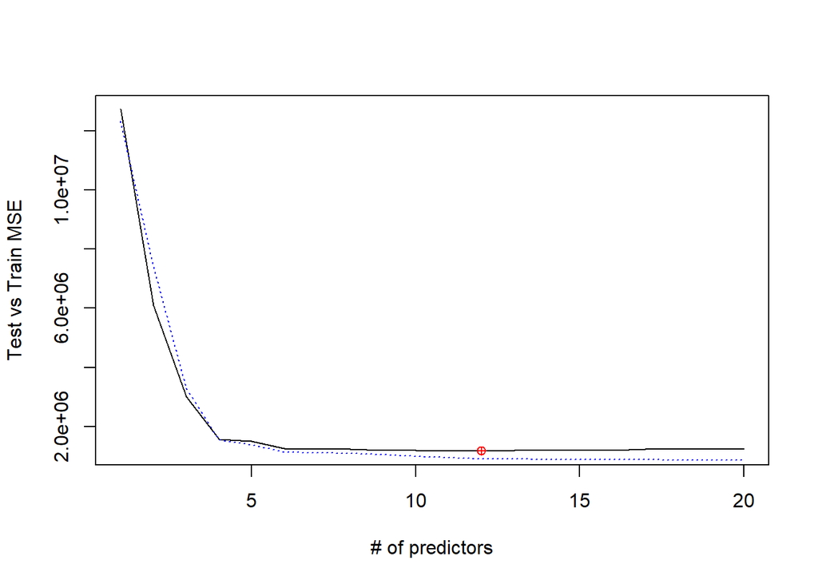

```r
predict.regsubsets =function (object , newdata ,id ,...){
  form=as.formula (object$call [[2]])
  mat=model.matrix(form ,newdata )
  coefi=coef(object ,id=id)
  xvars=names(coefi)
  mat[,xvars]%*%coefi
}

testASE<-c()
#note my index is to 20 since that what I set it in regsubsets
for (i in 1:20){
  predictions<-predict.regsubsets(object=reg.bkd,newdata=ddsdata_test,id=i)
  testASE[i]<-mean((ddsdata_test$MonthlyIncome-predictions)^2)
}

par(mfrow=c(1,1))
plot(1:20,testASE,type="l",xlab="# of predictors",ylab="Test vs Train MSE")
index<-which(testASE==min(testASE))
points(index,testASE[index],col="red",pch=10)
rss<-summary(reg.bkd)$rss
lines(1:20,rss/1022,lty=3,col="blue")
```

## BIC, adj R-squared and RSS plots for backward selection

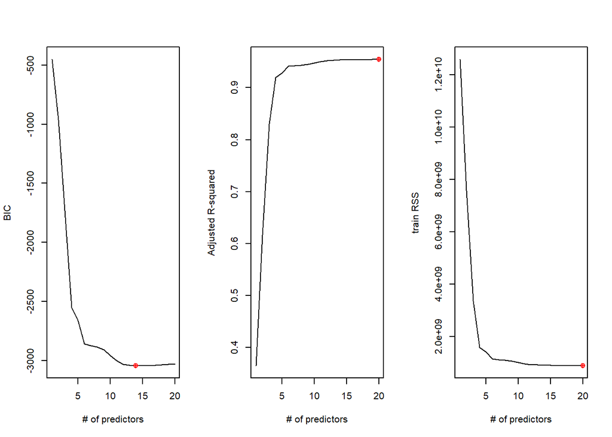

```r
par(mfrow=c(1,3))
bics<-summary(reg.bkd)$bic
plot(1:20,bics,type="l",ylab="BIC",xlab="# of predictors")
index<-which(bics==min(bics))
points(index,bics[index],col="red",pch=10)

adjr2<-summary(reg.bkd)$adjr2
plot(1:20,adjr2,type="l",ylab="Adjusted R-squared",xlab="# of predictors")
index<-which(adjr2==max(adjr2))
points(index,adjr2[index],col="red",pch=10)

rss<-summary(reg.bkd)$rss
plot(1:20,rss,type="l",ylab="train RSS",xlab="# of predictors")
index<-which(rss==min(rss))
points(index,rss[index],col="red",pch=10)
```

## Pick up the model

```r
m1<-coef(reg.bkd, 11)
m1
```

```
##                  (Intercept)                    JobLevel2
##                     3990.980                     1561.736
##                    JobLevel3                    JobLevel4
##                     4474.071                     7768.141
##                    JobLevel5       JobRoleHuman Resources
##                    10655.192                    -1693.849
## JobRoleLaboratory Technician               JobRoleManager
##                    -1690.937                     3329.691
##     JobRoleResearch Director    JobRoleResearch Scientist
##                     3502.146                    -1414.387
##  JobRoleSales Representative            TotalWorkingYears
##                    -1694.296                       46.730
```

```r
bkd.Model1 = lm(MonthlyIncome~ TotalWorkingYears + JobRole + JobLevel , data=ddsdata_train_upsample)
summary(bkd.Model1)
```

```
##
## Call:
## lm(formula = MonthlyIncome ~ TotalWorkingYears + JobRole + JobLevel,
##     data = ddsdata_train_upsample)
##
## Residuals:
##     Min      1Q  Median      3Q     Max
## -2715.1  -586.6  -126.8   512.4  4243.7
##
## Coefficients:
##                                Estimate Std. Error t value Pr(>|t|)
## (Intercept)                    3821.569    171.657  22.263  < 2e-16 ***
## TotalWorkingYears                48.718      6.595   7.387 3.15e-13 ***
## JobRoleHuman Resources        -1534.127    230.915  -6.644 5.00e-11 ***
## JobRoleLaboratory Technician  -1533.453    165.924  -9.242  < 2e-16 ***
## JobRoleManager                 3479.362    224.112  15.525  < 2e-16 ***
## JobRoleManufacturing Director     5.618    164.310   0.034   0.9727
## JobRoleResearch Director       3650.776    204.997  17.809  < 2e-16 ***
## JobRoleResearch Scientist     -1256.355    170.260  -7.379 3.33e-13 ***
## JobRoleSales Executive          256.085    127.094   2.015   0.0442 *
## JobRoleSales Representative   -1532.922    188.808  -8.119 1.36e-15 ***
## JobLevel2                      1545.080    134.406  11.496  < 2e-16 ***
## JobLevel3                      4467.801    177.067  25.232  < 2e-16 ***
## JobLevel4                      7737.512    261.159  29.628  < 2e-16 ***
## JobLevel5                     10622.885    314.210  33.808  < 2e-16 ***
## ---
## Signif. codes:  0 '***' 0.001 '**' 0.01 '*' 0.05 '.' 0.1 ' ' 1
##
## Residual standard error: 978.8 on 1008 degrees of freedom
## Multiple R-squared:  0.9514, Adjusted R-squared:  0.9507
## F-statistic:  1516 on 13 and 1008 DF,  p-value: < 2.2e-16
```

## Let’s check the residual Sum of Squares, Mean Squared Error and Root Mean Squared Error for backward selection model

```r
#residual sum of squares
bkd.RSS = c(crossprod(bkd.Model1$residuals))
bkd.RSS
```

```
## [1] 965740925
```

```r
#Mean Squared Error
bkd.MSE = bkd.RSS / length(bkd.Model1$residuals)
bkd.MSE
```

```
## [1] 944952
```

```r
#Root MSE
bkd.RMSE = sqrt(bkd.MSE)
bkd.RMSE
```

```
## [1] 972.0864
```

```r
bkd.pred<-predict(bkd.Model1, newdata=ddsdata_test)
bkd.TestMSE<-mean((ddsdata_test$MonthlyIncome-bkd.pred)^2)

bkd.TESTRMSE = sqrt(bkd.TestMSE)
bkd.TESTRMSE
```

```
## [1] 1096.037
```